# Assignment 3

Suryoday T. Roy

January 25, 2018

## PART 1

```r
GC<-read.csv("C:\\Users\\suryo\\Desktop\\german_credit (1).csv",header=TRUE,sep=",")
head(GC,1)
```

```
##   Creditability Account.Balance Duration.of.Credit..month.
## 1             1               1                         18
##   Payment.Status.of.Previous.Credit Purpose Credit.Amount
## 1                                 4       2          1049
##   Value.Savings.Stocks Length.of.current.employment Instalment.per.cent
## 1                    1                            2                   4
##   Sex...Marital.Status Guarantors Duration.in.Current.address
## 1                    2          1                           4
##   Most.valuable.available.asset Age..years. Concurrent.Credits
## 1                             2          21                  3
##   Type.of.apartment No.of.Credits.at.this.Bank Occupation No.of.dependents
## 1                 1                          1          3                1
##   Telephone Foreign.Worker
## 1         1              1
```

#### Remove all numeric data [considering all categorical variables]

```r
GC<-GC[c(-1,-3,-6,-9,-12,-14,-17,-19)]
GC<-as.data.frame(GC)
for (i in 1:ncol(GC)){
GC[,i]<-as.factor(GC[,i])}
str(GC)
```

```
## 'data.frame':    1000 obs. of  13 variables:
##  $ Account.Balance                  : Factor w/ 4 levels "1","2","3","4": 1 1 2 1 1 1 1 1 4 2 ...
##  $ Payment.Status.of.Previous.Credit: Factor w/ 5 levels "0","1","2","3",..: 5 5 3 5 5 5 5 5 5 3 ...
##  $ Purpose                          : Factor w/ 10 levels "0","1","2","3",..: 3 1 9 1 1 1 1 1 4 4 ...
##  $ Value.Savings.Stocks             : Factor w/ 5 levels "1","2","3","4",..: 1 1 2 1 1 1 1 1 1 3 ...
##  $ Length.of.current.employment     : Factor w/ 5 levels "1","2","3","4",..: 2 3 4 3 3 2 4 2 1 1 ...
##  $ Sex...Marital.Status             : Factor w/ 4 levels "1","2","3","4": 2 3 2 3 3 3 3 3 2 2 ...
##  $ Guarantors                       : Factor w/ 3 levels "1","2","3": 1 1 1 1 1 1 1 1 1 1 ...
##  $ Most.valuable.available.asset    : Factor w/ 4 levels "1","2","3","4": 2 1 1 1 2 1 1 1 3 4 ...
##  $ Concurrent.Credits               : Factor w/ 3 levels "1","2","3": 3 3 3 3 1 3 3 3 3 3 ...
##  $ Type.of.apartment                : Factor w/ 3 levels "1","2","3": 1 1 1 1 2 1 2 2 2 1 ...
##  $ Occupation                       : Factor w/ 4 levels "1","2","3","4": 3 3 2 2 2 2 2 2 1 1 ...
##  $ Telephone                        : Factor w/ 2 levels "1","2": 1 1 1 1 1 1 1 1 1 1 ...
##  $ Foreign.Worker                   : Factor w/ 2 levels "1","2": 1 1 1 2 2 2 2 2 1 1 ...
```

```r
for (i in c(2,3)){
  for (j in 1:nrow(GC))
  GC[,i]<-as.numeric(GC[,i])
  GC[j,i]<-GC[j,i]+1
  GC[,i]<-as.factor(GC[,i])}

str(GC)
```

```
## 'data.frame':    1000 obs. of  13 variables:
##  $ Account.Balance                  : Factor w/ 4 levels "1","2","3","4": 1 1 2 1 1 1 1 1 4 2 ...
##  $ Payment.Status.of.Previous.Credit: Factor w/ 5 levels "1","2","3","4",..: 5 5 3 5 5 5 5 5 5 3 ...
##  $ Purpose                          : Factor w/ 10 levels "1","2","3","4",..: 3 1 9 1 1 1 1 1 4 4 ...
##  $ Value.Savings.Stocks             : Factor w/ 5 levels "1","2","3","4",..: 1 1 2 1 1 1 1 1 1 3 ...
##  $ Length.of.current.employment     : Factor w/ 5 levels "1","2","3","4",..: 2 3 4 3 3 2 4 2 1 1 ...
##  $ Sex...Marital.Status             : Factor w/ 4 levels "1","2","3","4": 2 3 2 3 3 3 3 3 2 2 ...
##  $ Guarantors                       : Factor w/ 3 levels "1","2","3": 1 1 1 1 1 1 1 1 1 1 ...
##  $ Most.valuable.available.asset    : Factor w/ 4 levels "1","2","3","4": 2 1 1 1 2 1 1 1 3 4 ...
##  $ Concurrent.Credits               : Factor w/ 3 levels "1","2","3": 3 3 3 3 1 3 3 3 3 3 ...
##  $ Type.of.apartment                : Factor w/ 3 levels "1","2","3": 1 1 1 1 2 1 2 2 2 1 ...
##  $ Occupation                       : Factor w/ 4 levels "1","2","3","4": 3 3 2 2 2 2 2 2 1 1 ...
##  $ Telephone                        : Factor w/ 2 levels "1","2": 1 1 1 1 1 1 1 1 1 1 ...
##  $ Foreign.Worker                   : Factor w/ 2 levels "1","2": 1 1 1 2 2 2 2 2 1 1 ...
```

#### Creating Train and Test Samples

```r
set.seed(10001)
ind <- sample(c(TRUE, FALSE), nrow(GC), replace=TRUE, prob=c(0.632, 0.368))
dataTrain <-(GC[ind, ])
dataTest<- (GC[!ind, ])
```

#### Q1 and Q2 : Running LCA on Train sample and interpreting solution

```r
library(poLCA)
names(dataTrain)
```

```
##  [1] "Account.Balance"
##  [2] "Payment.Status.of.Previous.Credit"
##  [3] "Purpose"
##  [4] "Value.Savings.Stocks"
##  [5] "Length.of.current.employment"
##  [6] "Sex...Marital.Status"
##  [7] "Guarantors"
##  [8] "Most.valuable.available.asset"
##  [9] "Concurrent.Credits"
## [10] "Type.of.apartment"
## [11] "Occupation"
## [12] "Telephone"
## [13] "Foreign.Worker"
```

```r
lcF<-cbind(Account.Balance,Payment.Status.of.Previous.Credit,Purpose,Sex...Marital.Status,Guarantors,Most.valuable.available.asset,Concurrent.Credits,Type.of.apartment,Occupation,Telephone,Foreign.Worker)~1
```

```r
AIC<-numeric()
BIC<-numeric()
for(i in 2:10){
results=poLCA(lcF,dataTrain,nclass=i,nrep=100,tol=.001,verbose=FALSE, graphs=FALSE)
AIC[i]<-results$aic
BIC[i]<-results$bic
}
```

```r
ICs<-as.data.frame(rbind(AIC[-1],BIC[-1]))
colnames(ICs)<-2:10

ICs[3,]<-1.5*ICs[1,]+ICs[2,]
rownames(ICs)<-c("AIC","BIC", "1.5*AIC+BIC")
ICs
```

```
##                    2        3        4        5        6        7        8
## AIC         12830.17 12673.15 12620.65 12574.02 12552.33 12540.40 12524.17
## BIC         13128.77 13123.28 13222.31 13327.22 13457.06 13596.66 13731.95
## 1.5*AIC+BIC 32374.03 32133.00 32153.29 32188.26 32285.56 32407.27 32518.20
##                    9       10
## AIC         12534.92 12532.04
## BIC         13894.24 14042.89
## 1.5*AIC+BIC 32696.62 32840.96
```

```r
which(ICs[3,]==min(ICs[3,]))+1
```

```
## [1] 3
```

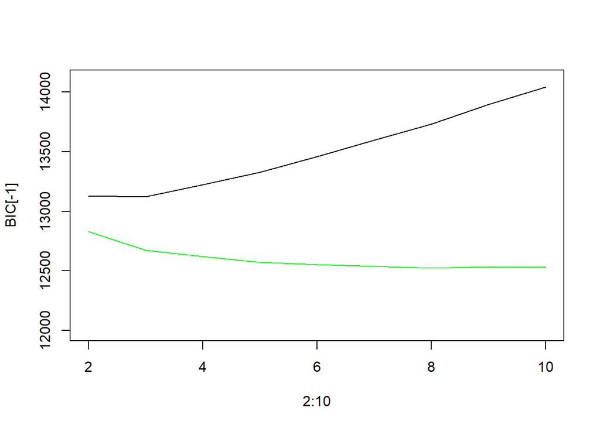

```r
plot(2:10,BIC[-1],type = 'l',ylim = c(12000,14100))
lines(2:10,AIC[-1],col='green')
```

#### Choosing Number of clusters:

Choose n=3 as this where both AIC,BIC elbow appears. Also, as seen in the table above, it is at n=3 that 1.5*AIC+BIC value is at its minimum. AIC has been given 50% more importance due to BIC’s inherent bias towards smaller class sizes

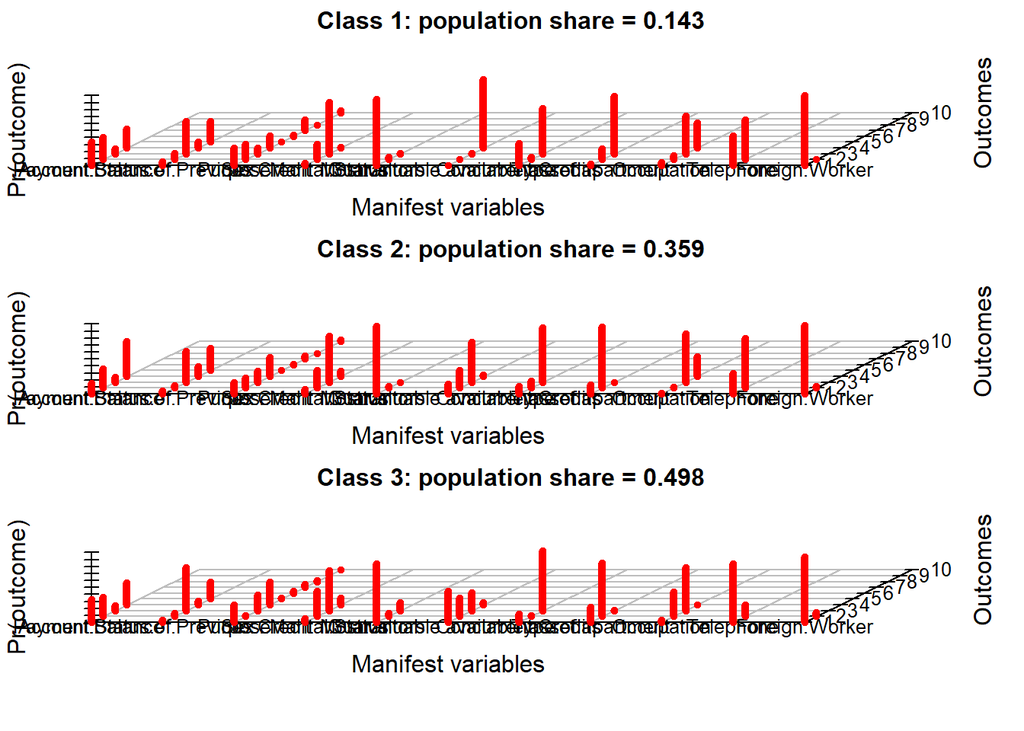

```r
result3 <- poLCA(lcF,dataTrain,nclass=3,nrep=100,tol=.001,verbose=FALSE, graphs=TRUE)
```

```r
result3$npar
```

```
## [1] 101
```

```r
table(result3$predclass)
```

```
##
##   1   2   3
##  93 216 328
```

```r
result3$probs
```

```
## $Account.Balance
##                   1         2          3         4
## class 1:  0.3364512 0.3174069 0.07706636 0.2690756
## class 2:  0.1557220 0.2744936 0.07056674 0.4992177
## class 3:  0.3238594 0.2815688 0.07200968 0.3225621
##
## $Payment.Status.of.Previous.Credit
##                    1          2         3          4         5
## class 1:  0.04981215 0.09530416 0.4668196 0.09088946 0.2971747
## class 2:  0.04602315 0.03741871 0.4501131 0.14496941 0.3214756
## class 3:  0.03133926 0.05285913 0.6163153 0.05856342 0.2409229
##
## $Purpose
##                   1          2          3         4           5          6
## class 1:  0.2481931 0.22162155 0.08521178 0.1762486 0.008526134 0.01625789
## class 2:  0.1594714 0.15051531 0.15796040 0.2792398 0.009311915 0.01194157
## class 3:  0.2550811 0.01712531 0.22409428 0.3248804 0.012902379 0.02769510
##                    7            8          9         10
## class 1:  0.15797351 0.000000e+00 0.05388684 0.03208066
## class 2:  0.05051182 2.767189e-06 0.15881261 0.02223237
## class 3:  0.04438042 1.889929e-02 0.07494172 0.00000000
##
## $Sex...Marital.Status
##                    1         2         3          4
## class 1:  0.03051571 0.2195805 0.7389336 0.01097011
## class 2:  0.06429816 0.2574976 0.6042010 0.07400318
## class 3:  0.05520520 0.3596319 0.4809464 0.10421650
##
## $Guarantors
##                   1          2            3
## class 1:  0.9533357 0.03482700 0.0118373403
## class 2:  0.9706776 0.02919660 0.0001257892
## class 3:  0.8423224 0.04460069 0.1130769019
##
## $Most.valuable.available.asset
##                      1            2          3          4
## class 1:  1.241173e-06 7.487833e-56 0.01271129 0.98728747
## class 2:  1.375664e-01 2.571150e-01 0.57967435 0.02564425
## class 3:  4.459014e-01 2.652879e-01 0.25928251 0.02952818
##
```

[output cut: 14 more lines]

```
## class 1:  0.040886001 0.06211866 0.5406831 0.3563122460
## class 2:  0.008768323 0.01508353 0.6947939 0.2813542805
## class 3:  0.029227285 0.35567010 0.6142363 0.0008662723
##
## $Telephone
##                   1         2
## class 1:  0.4279351 0.5720649
## class 2:  0.2915109 0.7084891
## class 3:  0.8361953 0.1638047
##
## $Foreign.Worker
##                   1             2
## class 1:  1.0000000 3.322673e-179
## class 2:  0.9778622  2.213783e-02
## class 3:  0.9403401  5.965987e-02
```

#### Since the proportion of foreign workers and guarantors are high in all classes, we can consider dropping these varaibles and looking at improvements in cluster interpretability.

```r
lcF<-cbind(Account.Balance,Payment.Status.of.Previous.Credit,Purpose,Sex...Marital.Status,Most.valuable.available.asset,Concurrent.Credits,Type.of.apartment,Occupation,Telephone)~1
AIC<-numeric()
BIC<-numeric()
for(i in 2:6){
results=poLCA(lcF,dataTrain,nclass=i,nrep=100,tol=.001,verbose=FALSE, graphs=FALSE)
AIC[i]<-results$aic
BIC[i]<-results$bic
}
```

```r
ICs<-as.data.frame(rbind(AIC[-1],BIC[-1]))
colnames(ICs)<-2:6

ICs[3,]<-1.5*ICs[1,]+ICs[2,]
rownames(ICs)<-c("AIC","BIC", "AIC+BIC")
ICs
```

```
##                2        3        4        5        6
## AIC     12141.99 12002.58 11955.76 11911.82 11896.16
## BIC     12413.85 12412.61 12503.95 12598.16 12720.66
## AIC+BIC 30626.84 30416.49 30437.59 30465.88 30564.89
```

```r
which(ICs[3,]==min(ICs[3,]))+1
```

```
## [1] 3
```

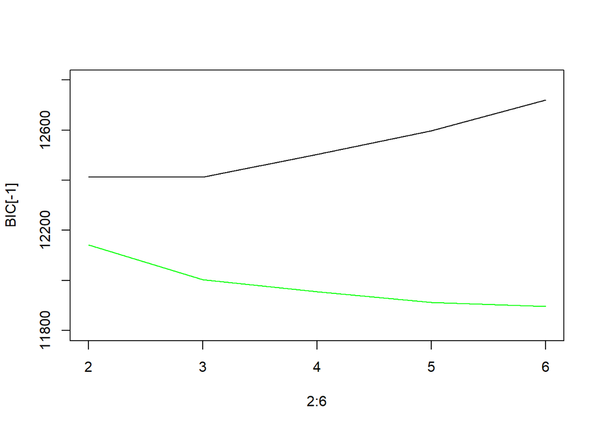

```r
plot(2:6,BIC[-1],type = 'l',ylim = c(11800,12800))
lines(2:6,AIC[-1],col='green')
```

#### Re-looking at the choice of number of classes, we can see that after dropping the two variables, the AIC and BIC values have both improved. Plotting the values as well as looking at the AIC+BIC sum, we can once agin conclude that n=3 has the optimum solution.

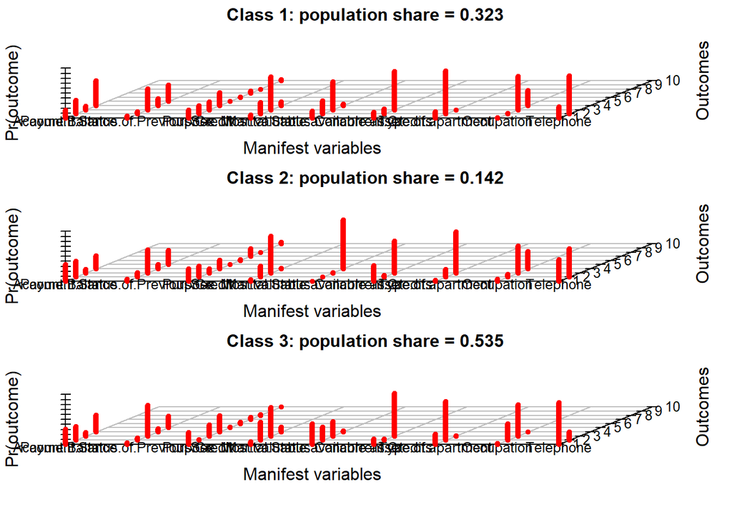

```r
result3 <- poLCA(lcF,dataTrain,nclass=3,nrep=100,tol=.001,verbose=FALSE, graphs=TRUE)
```

```r
result3$npar
```

```
## [1] 92
```

```r
table(result3$predclass)
```

```
##
##   1   2   3
## 200  90 347
```

```r
result3$probs
```

```
## $Account.Balance
##                   1         2          3         4
## class 1:  0.1589233 0.2717092 0.06954266 0.4998248
## class 2:  0.3361561 0.3212440 0.07740475 0.2651952
## class 3:  0.3108270 0.2818055 0.07244929 0.3349181
##
## $Payment.Status.of.Previous.Credit
##                    1          2         3          4         5
## class 1:  0.04612311 0.04686675 0.4239444 0.14560874 0.3374570
## class 2:  0.04942830 0.09488776 0.4709640 0.09045999 0.2942599
## class 3:  0.03238028 0.04627810 0.6198028 0.06408008 0.2374588
##
## $Purpose
##                   1          2          3         4           5
## class 1:  0.1627836 0.16855806 0.15572574 0.2602199 0.008588462
## class 2:  0.2537304 0.22044890 0.08307816 0.1761520 0.008685397
## class 3:  0.2452346 0.01564607 0.22144465 0.3331952 0.013053460
##                     6          7             8          9            10
## class 1:  0.009523122 0.04707133  3.205771e-24 0.16230383  2.522604e-02
## class 2:  0.016090453 0.15784535 4.255122e-266 0.05298996  3.097941e-02
## class 3:  0.028140404 0.04704062  1.762063e-02 0.07862441 1.041880e-174
##
## $Sex...Marital.Status
##                    1         2         3          4
## class 1:  0.06698652 0.2340093 0.6250122 0.07399202
## class 2:  0.02970225 0.2238792 0.7354146 0.01100392
## class 3:  0.05437056 0.3657321 0.4778061 0.10209122
##
## $Most.valuable.available.asset
##                      1            2          3          4
## class 1:  0.1449496660 2.612786e-01 0.56393288 0.02983886
## class 2:  0.0002641491 2.459911e-09 0.01241826 0.98731758
## class 3:  0.4203083227 2.619057e-01 0.28990759 0.02787838
##
## $Concurrent.Credits
##                   1          2         3
## class 1:  0.1247821 0.10561788 0.7696000
## class 2:  0.3152862 0.03930686 0.6454069
## class 3:  0.1138324 0.02257520 0.8635924
##
## $Type.of.apartment
##                    1         2            3
## class 1:  0.13102068 0.8689793 9.197620e-83
## class 2:  0.01866042 0.1541612 8.271784e-01
## class 3:  0.21239690 0.7813386 6.264461e-03
##
## $Occupation
##                     1          2         3           4
## class 1:  0.008843839 0.01184813 0.6720319 0.307276178
## class 2:  0.041048702 0.06272306 0.5416151 0.354613169
## class 3:  0.027790869 0.33444695 0.6330303 0.004731919
##
## $Telephone
##                   1         2
## class 1:  0.2300323 0.7699677
## class 2:  0.4327982 0.5672018
## class 3:  0.8353518 0.1646482
```

#### Interpreting Classes based on Graph and Probabilities:

Class 1 :  
Has the 2nd highest population share 32%  
This class has got skilled employees/officials(occupation=3) customers who have no checking account (account balance=4) but own their apartment (type of Apartment=2). These customers may be easier to target and to reach as they have a phone registered to their name.

Class 2: This is the smalles class with roughly 14% of the population share.  
This class is characterised by single male (Sex&Marital Status=3) customers who do not own any real estate(most valuable asset=4) and live rent free (Type of apartment=3) i.e. these customers can be characterised as dependent males.

#### Question 3 and 4

Holdout Testing:

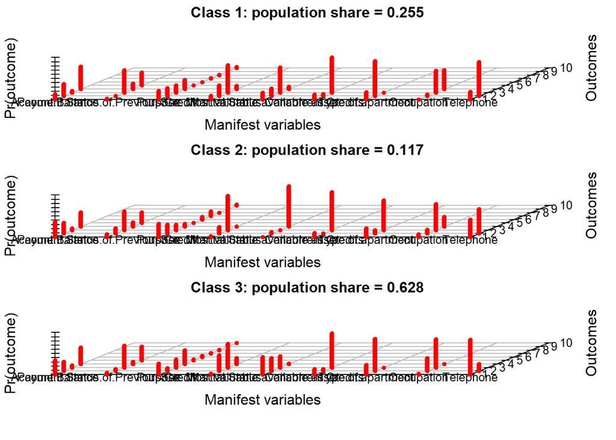

```r
test<-poLCA(lcF,dataTest,nclass=3,probs.start = result3$probs,tol=0.1,verbose = FALSE,graphs = TRUE)
```

```r
test$aic
```

```
## [1] 6804.464
```

```r
test$bic
```

```
## [1] 7162.749
```

```r
test$probs
```

```
## $Account.Balance
##                   1         2          3         4
## class 1:  0.1343943 0.2860457 0.03996127 0.5395987
## class 2:  0.3652250 0.2549441 0.04333068 0.3365002
## class 3:  0.3380217 0.2223680 0.05027590 0.3893344
##
## $Payment.Status.of.Previous.Credit
##                    1            2         3          4         5
## class 1:  0.02280571 5.125619e-08 0.5351000 0.12769944 0.3143948
## class 2:  0.06809508 1.210890e-01 0.4495426 0.10074289 0.2605304
## class 3:  0.04385714 4.324889e-02 0.5236585 0.05657922 0.3326562
##
## $Purpose
##                   1          2         3          4            5
## class 1:  0.2117190 0.18888468 0.1675395 0.22487707 3.847395e-19
## class 2:  0.3153438 0.21467844 0.1334383 0.06828724 1.102171e-58
## class 3:  0.2676373 0.07191399 0.1922467 0.32587415 2.193702e-02
##                      6          7             8          9            10
## class 1:  9.490206e-12 0.01541895  1.113377e-02 0.15103977  2.938724e-02
## class 2:  6.870567e-02 0.11485481 1.867931e-298 0.05458573  3.010598e-02
## class 3:  2.668492e-02 0.01620876  8.638555e-03 0.06885857 5.843243e-156
##
## $Sex...Marital.Status
##                    1         2         3            4
## class 1:  0.08622035 0.2557195 0.5757731 8.228704e-02
## class 2:  0.02363149 0.1615668 0.8148017 2.207614e-27
## class 3:  0.02637648 0.3793230 0.4478502 1.464503e-01
##
## $Most.valuable.available.asset
##                      1          2            3          4
## class 1:  1.603799e-01 0.18108857 5.971756e-01 0.06135589
## class 2:  6.243546e-21 0.03533605 3.479842e-14 0.96466395
## class 3:  4.130646e-01 0.31031851 2.663060e-01 0.01031089
##
## $Concurrent.Credits
##                   1            2         3
## class 1:  0.1155334 4.465475e-02 0.8398119
## class 2:  0.1001220 5.107090e-44 0.8998780
## class 3:  0.1362239 4.328040e-02 0.8204957
##
## $Type.of.apartment
##                   1          2            3
## class 1:  0.1698750 0.83012503 1.378797e-98
## class 2:  0.2123805 0.08121563 7.064038e-01
## class 3:  0.2336250 0.76637502 3.839001e-30
##
## $Occupation
##                      1          2         3            4
## class 1:  3.735561e-10 0.03253529 0.5222555 4.452092e-01
## class 2:  6.302204e-02 0.09284837 0.6141499 2.299797e-01
## class 3:  1.896912e-02 0.31169828 0.6693153 1.734265e-05
##
## $Telephone
##                   1         2
## class 1:  0.1874329 0.8125671
## class 2:  0.4136512 0.5863488
## class 3:  0.8339375 0.1660625
```

#### Q5. Comparison against K-Means Clusters:

1. There is greater chance of overlaps between LCA classes as opposed to the generally mutually exclusive nature of the K-means clusters thus making K-means the more interpretable of the two solutions
2. In terms of performance between train and test, K-means seems to show more stability and is again the more preferred of the two solutions.
3. While K-Means worked only with numerical data, LCA worked only with Categorical data and thus the two can be seen as collectively exhaustive and mutually exclusive techniques thus making their comparability quite low generally.
4. While K-Means generated a solution with approximately equal sizes of the clusters, LCA’s classes have greater variability in class sizes.
5. LCA solutions seem to prefer smaller number of classes as compared to K-means clusters(3 LCA classes as opposed to 7 clsuters in k-means)